# Discussion 5

Group Member Names Here

# Preliminaries

- This file should be in `STAT240/discussion/ds05`.
- This assignment should be completed in your discussion groups, which can be found on the “People” tab on Canvas.

The goal of today’s discussion will be to develop a stronger conceptual understanding of sampling distributions and simulation.

# Problem 1

#### (approx. 15 minutes)

The trading-card-game “WOW! WIZARD BATTLE!” is sold in packs of 15 randomized playing cards. $X$, the number of legendary wizard cards per pack, is random and has the following distribution.

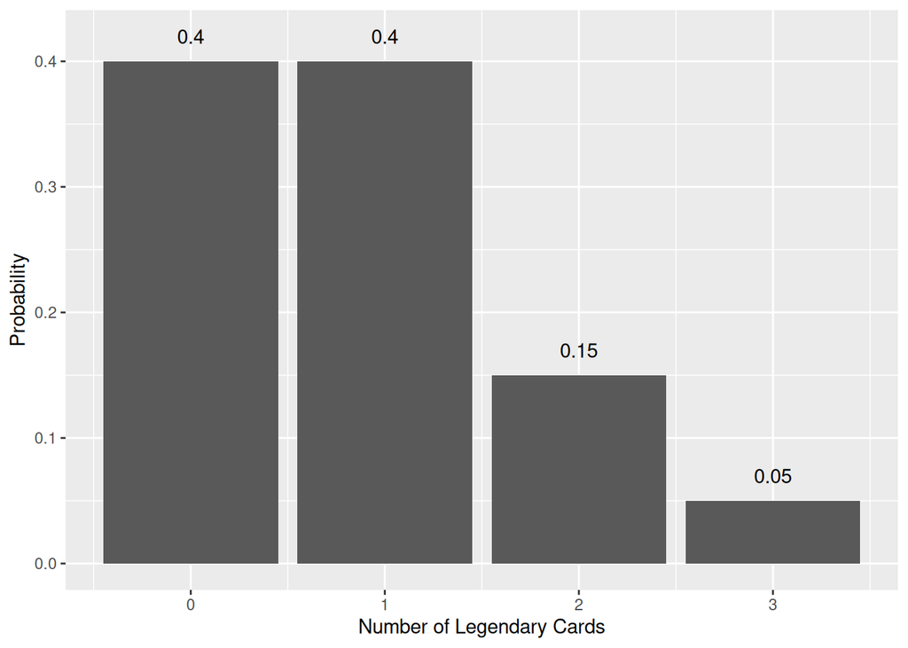

```r
values <- 0:3
probs <- c(0.4, 0.4, 0.15, 0.05)

ggplot(mapping = aes(x = values, y = probs)) +
  geom_col() +
  geom_text(aes(label = probs, x = values, y = probs+0.02)) +
  labs(x = "Number of Legendary Cards", y = "Probability")
```

Early in the day, a customer purchases 40 card packs from a store. Later, another customer visits the same store and purchases the remaining 5 card packs.

# Problem 2

#### (approx. 15 minutes)

The `sprint` dataframe defined below gives the sprinting speed (in mph) of 25 random 21-30 year old women. The histogram, sample mean, and sample SD of sprint speeds are also given to you.

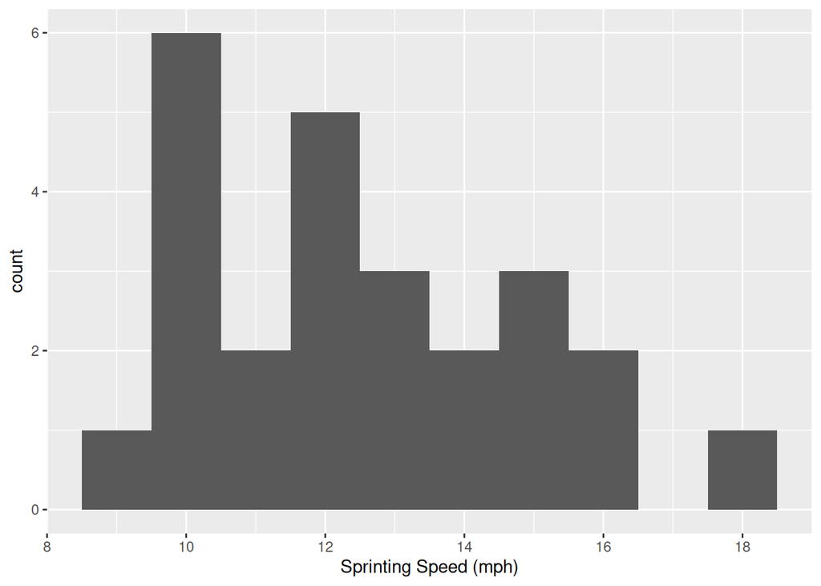

```r
sprint <- tibble(
  participant = 1:25,
  speed = c(10.0, 14.8, 12.1, 13.5, 9.8, 9.9, 15.3, 11.2,
            10.5, 11.8, 11.3, 10.1, 9.3, 12.5, 12.7, 16.2,
            15.3, 14.2, 13.8, 12.7, 12.0, 10.2, 18.3, 15.9, 12.5)
)

ggplot(sprint, mapping = aes(x = speed)) +
  geom_histogram(binwidth = 1) +
  labs(x = "Sprinting Speed (mph)")
```

```r
sprint %>%
  summarize(avg_speed = mean(speed),
            sd_speed = sd(speed))
```

```
## # A tibble: 1 × 2
##   avg_speed sd_speed
##       <dbl>    <dbl>
## 1      12.6     2.37
```

1. Each group member should separately resample 25 observations from the `sprint` dataframe, and recalculate the sample SD from those 25 resampled observations. You can use the `new_data()` function below. Your group should be left with 3-4 different values of sample SD.

```r
new_data <- function(data, n) {
  sample_n(data, size = n, replace = TRUE)
}
```

2. Based on the 3 or 4 different values of sample SD, what do you think counts as a “typical” value for sample SD? In this context, how much do you think the sample SD will vary from sample to sample?
3. Perform a resampling experiment with the `replicate()` function to study the sampling distribution of the SD. Do not do 10000 replications - for this part, only do 100 replications. Create a histogram of the 100 sample SDs, and also calculate the average and standard deviation of the 100 sample SDs.
4. Repeat part (c), but do an experiment with 1000 replications and finally an experiment with 10000 replications. Create a histogram and calculate the numeric summaries for each.

For all parts of (c) and (d), make sure you are always resampling 25 rows at each step.

5. What do you notice as you increase the number of resamples? Why is it necessary to produce a large number of resamples when studying the sampling distribution of a statistic?

# Problem 3

#### (approx. 10 minutes)

Continue working with the `sprint` data from problem 2.

1. Perform a resampling experiment with 10000 resamples to study the *sample maximum* of the data. Create a histogram of the 10000 sample maximums and comment on its shape. Also calculate the average value of these sample maximums.
2. The sample maximum is an example of a statistic with **negative bias** - it systematically underestimates the true maximum. Based on your histogram, explain how the *resampled maximum* underestimates the *data maximum* of 18.3.
3. Using a similar line of reasoning to (b), explain how the *data maximum* of 18.3 is most likely an underestimate of the true population maximum sprinting speed for this group of women.